# Rapport de stage

2025-06-02

# Présentation de la structure

## a) Présentation générale

L’Office Français de la Biodiversité (OFB) est un établissement public français créé le 1er janvier 2020. L’Office National de la Chasse et de la Faune Sauvage (ONCFS), créé en 2000, s’est uni à l’Agence Française de la Biodiversité, créé en 2017. L’OFB met en oeuvre des actions visant à la protection et la à restauration de la biodiversité terrestre et marine.

Les agents s’engagent dans la lutte contre les cinq causes majeures de la dégradation de la biodiversité : la destruction et la fragmentation des milieux naturels, les pollutions, la surexploitation des ressources, l’introduction d’espèces exotiques envahissantes et les conséquences du changement climatique (IPBES,2019). Les services de l’OFB s’articulent également autour des missions complémentaires suivantes : la police de l’environnement; la connaissance/recherche et l’expertise sur les espèces, leurs milieux et leurs usages; l’appui à la mise en oeuvre des politiques publique; la gestion et l’appui aux gestionnaires d’espaces naturels et pour terminer l’appui aux acteurs et à la mobilisation de la société.

## b) OFB Bretagne

La Direction Régionale Bretagne de l’OFB regroupe 130 agents répartis sur toute la région. Trois services sont établis dans ses locaux : “Appui aux acteurs et mobilisation des territoires”, “Police” et “Connaissance”. Le présent stage se déroule dans le service Connaissance, sous la tutelle d’Yves-Marie (chef adjoint du service connaissance) , Thibault Vigneron (chef du service connaissance) et Pascal Irz (ingénieur connaissance).

# Contexte général

## Les pressions anthropiques en milieux d’eau douce

Les cours d’eau subissent des pressions d’origine hydromorphologique et polluante, qui entraînent de nombreuses dégradations sur l’état des milieux aquatiques, incluant les populations qui les peuplent. Depuis le développement des industries, de l’agriculture intensive et l’urbanisation à partir au XIX siècle, l’intensité des perturbations n’a cessé d’augmenter.

Ces milieux sont notamment soumis à des modifications morphologiques profondes telles que la chenalisation, l’artificialisation des berges, l’altération des régimes hydrologiques naturels, l’exploitation du lit du cours d’eau et le drainage des terres ainsi que des zones humides. Ces altérations peuvent avoir des conséquences significatives sur l’habitat et le fonctionnement global de l’écosystème.

A cela s’ajoute la pollution chimique, issue de rejets d’origines multiples. Elles peuvent être diffuses ou ponctuelles. En Bretagne, seulement 51% des cours d’eau sont en bon état chimique, en ne prenant en compte que les 53 substances prioritaires non ubiquistes. D’après les données de 2022 de l’OEB, 59% des masses d’eau sont concernés par les pollutions diffuses, dont les pesticides, phosphore et nitrates respectivement 57%, 15% et 12% (chiffres clés de l’eau en Bretagne, 2023).

L’état d’un milieu aquatique peut s’appréhender sous différents angles, notamment écologique et biologique. C’est dans cette optique qu’a été instaurée en 2000 la Directive Cadre sur l’Eau (DCE) par le Conseil européen et le conseil des ministres, intégrant la notion de bio-indication dans la méthodologie d’évaluation de l’état des milieux aquatiques. La DCE vise à prévenir et réduire la pollution des eaux, à promouvoir leur utilisation durable et améliorer l’état des écosystèmes aquatiques. Elle constitue également un cadre visant à gérer et protéger les eaux européennes. Les états membres sont dans l’obligation d’évaluer la qualité écologique de leurs masses d’eau et de restaurer ou maintenir leur bon état écologique d’ici 2027. Les éléments de qualité biologiques (EQB) retenues sont : les poissons, les macrophytes, les macro-invertébrés et les diatomées. Cette évaluation de l’état d’un milieu est permise grâce à une classifications qui distingues les cours d’eau de références, définis comme ceux présentant les caractéristiques attendues en l’absence de pression humaines (concept de « conditions de référence » ; Bailey et al. 1998 et les cours d’eau altérés). La notion d’écart à un état de référence est intégrée dans le calcul des indices biologiques, et par conséquent dans l’évaluation de l’état écologique des masses d’eau, ils seront alors traduits en ratios de qualités biologiques. Les stations sont classées de la manière suivante : réseau de référence pérenne (RRP), réseau de contrôle de surveillance (RCS), réseau de contrôle opération (RCO).

En Bretagne, les trois-quarts des masses d’eau sont déclassés en raison de leur mauvaise qualité biologique. Les diatomées sont le deuxième groupe de bio-indicateur déclassant en Bretagne, suivi par les macroinvertébrés. Parmi les masses d’eau bretonnes, 55% d’entre elles sont classées comme médiocres par rapport aux paramètres physico-chimique soutenant l’état-écologique.

## Les éléments de qualité biologique étudiés

La bioévaluation permet la détermination de l’état d’un milieux, en s’appuyant sur des indicateurs biologiques. Ces indicateurs correspondent à des espèces biologiques ou animales, dont la présence, l’abondance ou l’état de santé reflète des modifications biotiques ou abiotiques de l’environnement dues à des activités humaines (https://eau-grandsudouest.fr/glossaire/b).

### L’Indice invertébrés multi-métriques

Selon la définition de Cummins (1975), les macroinvertébrés sont des organismes dont la taille atteint au moins 3 à 5 mm au dernier stade de leur développement. Cette définition inclut donc à la fois les jeunes stades des macroinvertébrés et les derniers stades des micro-invertébrés (Tachet). Ils sont présents dans tous les écosystèmes aquatiques, certains sont holobiotiques et d’autres amphibiotiques. Ils regroupent une grande variété de genres et espèces, dont la plupart sont indicatrices telles que : les ephéméroptères, plécoptères et trichoptères (EPT).

Les macroinvertébrés jouent un rôle essentiel dans les écosystèmes aquatiques en contribuant notamment à la transformation de la matière organique (accélération du cycle des nutriments), en servant de nourriture pour les poissons et en étant des indicateurs de pollution. En effet, ils regroupent un grand nombre de taxons ayant différents niveaux de tolérance à la pollution. Leur courte durée de génération permet aux communautés de réagir rapidement aux changements environnementaux. Certaines différences dans leurs cycles de vie, leurs caractéristiques physiologiques, leur mobilité et leur sensibilité individuelle à la pollution sont à l’origine de la construction d’indices basés sur les macroinvertébrés (Marzin et al., 2012 ; Alric et al., 2021). Parmi les éléments de qualité biologique (EQB), les indicateurs basés sur les macroinvertébrés sont les plus sensibles aux dégradations globales des cours d’eau (https://pastel.hal.science/pastel-00879788).

L’indice I2M2 permet d’évaluer la qualité écologique sur la base d’un écart à une référence, résultat en EQR (*Ecological quality ratio*). Cela implique donc d’établir des peuplements de référence par type de cours d’eau, et donc d’un réseau de référence. Ceux-ci sont seIectionnés sur la base de la taille du cours d’eau correspondant et de leur hydro-écorégion. L’indice est conçu pour identifier les tronçons de cours d’eau dégradés en lien avec 17 catégories de pressions anthropiques. Deux catégories de pressions sont prises en considération : pressions liées à la dégradation de la qualité de l’eau et celles liées à la dégradation de l’habitat. L’I2M2 prend en compte les caractéristiques taxonomiques et les traits biologiques des communautés de macroinvertébrés benthiques, avec une détermination des individus jusqu’au genre (et non plus seulement à la famille, ce qui était le cas avec l’IBGN). De plus, il intègre les abondances des genres recensés. L’échantillonnage est réalisé selon la norme NF T 90-333 dans l’AFNOR, 2016.

Les métriques retenues pour la construction de l’indice sont les suivantes :

- Indice de diversité de Shannon
- Richesse taxonomique
- Score ASPT (Average Score Per Taxon)
- Abondance relative de taxons polyvoltinistes
- Abondance relative de taxons ovovivipares

### L’Indice biologique diatomées

Les diatomées sont des algues brunes unicellulaires microscopiques, mesurant 5µm à 500µm. Elles appartiennent à l’embranchement des Chromophytes. Elles sont constituées d’un frustule siliceux et de matière organique végétale. Parmi les critères qui en font de bon bio-indicateurs : cycle de vie rapide (efficace pour les impacts qui ont lieu sur une courte durée), caractère cosmopolite, grande diversité, sensibilité variable à la pollution, échantillonage aisé, conservation en laboratoire facile.

Leur croissance est directement influencée par la température, l’intensité lumineuse, les caractéristiques hydrauliques et physico-chimiques. Les paramètres physico-chimiques influençant les diatomées sont : le pH, les nutriments (azotés et phosphorés), la présence de matière organique et une faible oxygénation en eaux. D’après l’étude (conductiv/ph), elles sont également sensibles à la conductivité. A mesure que la conductvité augmente, les espèces tolérantes à la conductivité élevée remplacent celles qui sont moins tolérantes.

L’IBD correspond à une valeur calculée à partir d’une analyse de la flore diatomique benthique d’un cours d’eau de France métropolitaine, selon la norme NF T90-354, avril 2016 (SANDRE). Il évalue plus particulièrement le niveau de pollution organique (saprobie) et trophique (nutriments azotés et phosphorés). Il prend en compte l’abondance de 209 taxons appariés, leur sensibilité à la pollution et leur faculté à s’adapter à différents milieux. A noter que l’indice de polluo-sensibilité spécifique, prend en compte la totalité des espèces présentes dans les inventaires et se base sur l’abondance relative ainsi que leur sensibilité à la pollution.

https://acces.ens-lyon.fr/acces/thematiques/biodiversite/dossiers-thematiques/biosurveillance-et-bioindicateurs/les-diatomees-bio-indicatrices-de-la-qualite-des-cours-d2019eau

# Contexte de l’étude

## Zone d’étude

La Bretagne est une région située au nord-ouest de la France. Son climat est marqué par un gradient ouest-est. Les précipitations y sont relativement abondantes à l’ouest, sous l’influence du climat océanique contrairement à l’est du territoire, où la pluviométrie y est deux fois moindre. En ce qui concerne la géologie, c’est un massif ancien, drainé par un réseau hydrographique d’environ 30 000 kilomètres (IBG, 2017). Au sens de la DCE, l’état des cours d’eau est très contrasté sur la Bretagne entre le département du Finistère (61% en bon état) et l’Ille-et-Vilaine (2% en bon état). A l’ouest de la Bretagne, la forte pente et la diversité morphologique des cours d’eau renforcent leur capacité de résilience. A l’inverse, en Ille-et-Vilaine, le déficit pluviométrique limite les débits, réduisant ainsi la capacité de dilution et d’autoépuration. Les principales pressions expliquant la non atteinte au bon état écologique des cours d’eeau en Bretagne sont la dégradation de la morphologie des cours d’eau, ainsi que l’intensification de l’agriculture laitière au sud de Rennes.

[figure not shown]

## Le phosphore et les nitrates dans les cours d’eau bretons

Malgré les améliorations, la concentration en phosphore reste élevée dans la majorité des cours d’eau bretons. Celle-ci est de 0,31 mg.L (percentile 90), émis notamment par les activités agricoles, le phosphore est largement transféré dans les cours d’eau pendant la période hivernale, où les pluies sont plus intenses. Le phosphore provenant d’industrie ou autre activité urbaine, est rejeté toute l’année, devenant alors une pollution diffuse continue. Cet apport devient d’autant plus majeur en période sèche. Un léger gradient de concentration, et donc de qualité, au regard des espèces phosphorées, s’exerce en Bretagne.

Plusieurs études ont montré la pertinence du phosphore total pour l’étude réponses biologiques des macro-invertébrés et autres indicateurs biologiques, notamment au niveau des sites les plus pollués. (https://www.sciencedirect.com/science/article/pii/S0048969723066214?via%3Dihub)

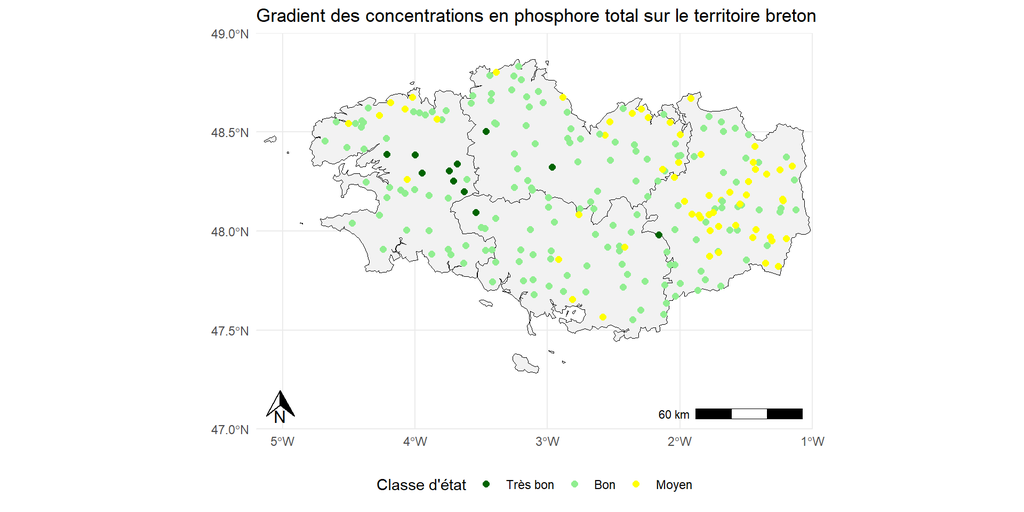

Fig.2 : Gradient de concentration en phosphore total en Bretagne, autrice : Ilona Garcia

La pollution azotée, notamment les nitrates, stagne à un niveau très élevé depuis 6 ans, c’est-à-dire 32,1 mg.L (percentile 90). La mesure de la concentration en nitrates est complétée d’une mesure débitmétrique car plus les débits sont importants plus les quantités en azote nitrique sortant du bassin versant sont élevées. Les formes de l’azote les plus toxiques sont l’ammonium (de part sa transformation aisée en ammoniac) et les nitrites, produites notamment par le biais de réactions acido-basique et oxydo-réductrices dans le cycle de l’azote, elles feront donc parties des espèces chimiques étudiées (https://www.sciencedirect.com/science/article/abs/pii/S1382668918302540).

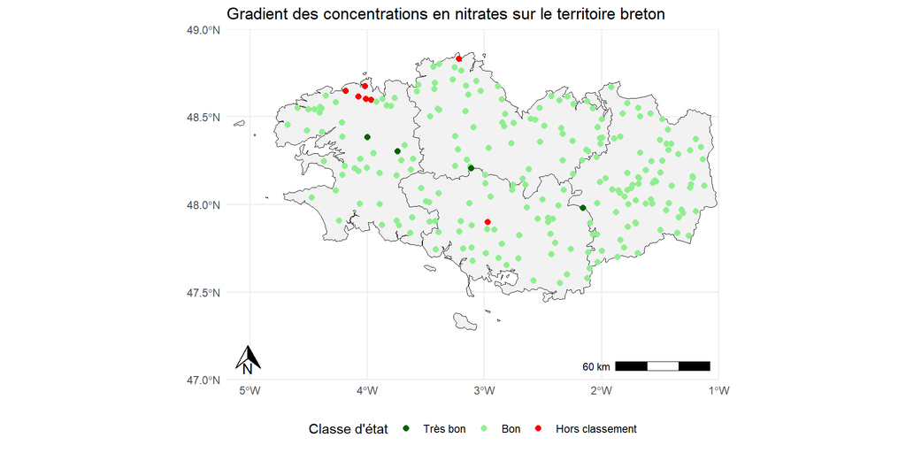

Fig.3 : Gradient de concentration en nitrates en Bretagne, autrice : Ilona Garcia

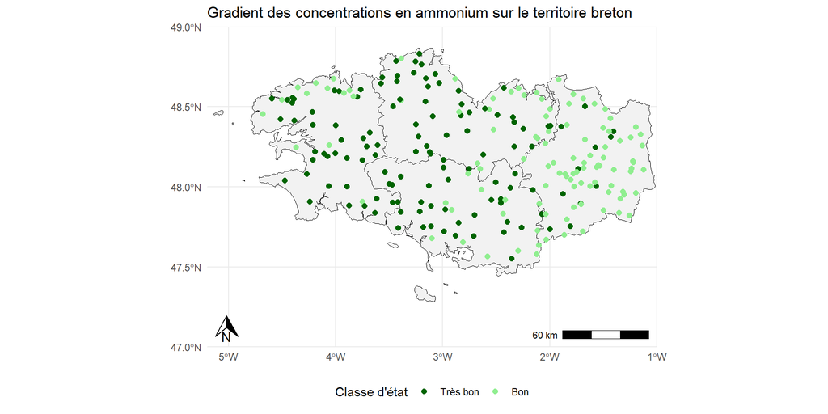

Fig.4 : Gradient de concentration en azote ammoniacal en Bretagne, autrice : Ilona Garcia

La concentration en nitrates est globalement uniforme, contrairement à l’ammonium dont la concentration s’accroit dans l’est de la région, de manière similaire au gradient de qualité des cours d’eau bretons.

## Cartes des classes d’états I2M2 et IBD

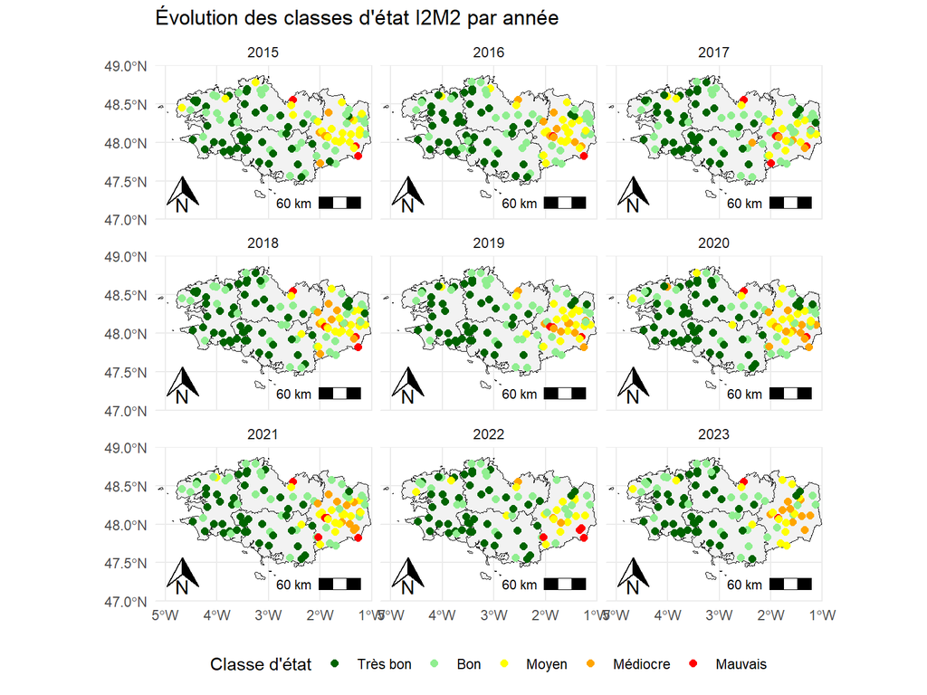

Fig.5 : Evolutions des notes I2M2 de chaque stations au cours du temps, autrice : Ilona Garcia

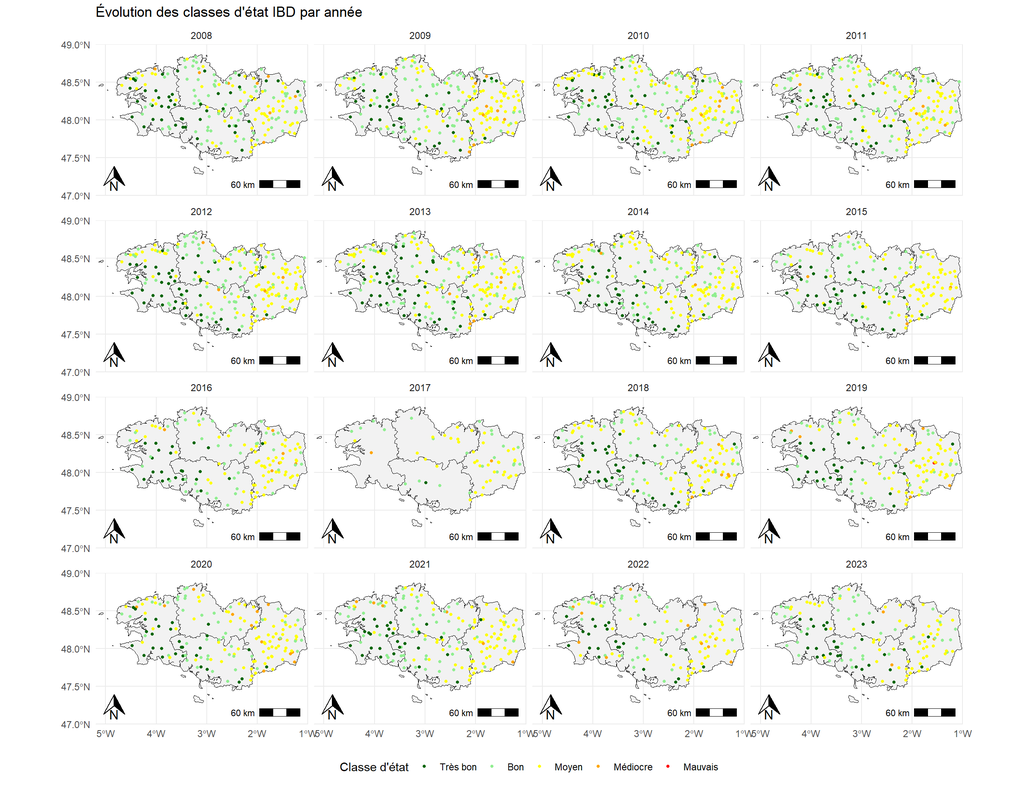

Fig.6 : Evolutions des notes IBD de chaque stations au cours du temps, autrice : Ilona Garcia

En 2023, 43% des stations présentent un état “Moyen” selon l’indice diatomées, contre 15% pour les macroinvertébrés, confirmant ainsi les tendances de déclassement précédemment mises en évidence en Bretagne. La majorité de ces stations se trouvent à l’est de la région.

# Objectif de l’étude

L’objectif de cette étude est d’analyser les réponses biologiques des macroinvertébrés et diatomées benthiques en lien avec les différents paramètres physico-chimiques retenues afin d’identifier des patterns écologiques généraux des cours d’eau bretons. En considérant les pressions constituants la construction de l’indice I2M2 et de les données bibliographiques retenues concernants les communautés diatomiques et macroinvertébrés, les éléments physico-chimiques selectionnés sont les suivants :

- Les matières azotées (nitrates, nitrites, ammonium)
- Les matières organiques et oxydables (carbone organique)
- Les matières phosphorées (phosphore total et othophosphates)
- Les matières en suspension
- L’acidification (pH) (https://www.frontiersin.org/journals/water/articles/10.3389/frwa.2021.662765/full) –> MI
- Conductivité (https://www.frontiersin.org/journals/water/articles/10.3389/frwa.2021.662765/full) –> MI
- Température –> Rhone

L’étude se porte premièrement sur l’étude des indices biologiques I2M2 et IBD et deuxièmement sur les groupes taxonomiques.

# Matériels et méthodes

## Bancarisation des données

Les données sont extraites à partir d’Hub’eau, service proposé par Eau France. Des API sont mis à disposition, ce qui favorise l’utilisation des données pour leur traitement sur le logiciel R. Cela permet la reproductibilité des scripts entre les utilisateurs.

## Sélection des données

### Prétraitement des indices biologiques

Après chargement des données complètes “macroinvertébrés”, seules les observations associées à l’I2M2 et ses métriques sont conservées. L’exploration porte sur la période 2015-2023, en raison du transfert non automatisé des données entre les portails SEEE et Hub’eau. Les données relatives à l’IBD, appliqué en 2003, couvrent une période plus étendue (2005-2023). Toutefois, les années 2005 à 2007 ont été exclues en raison du nombre insuffisant de données, lié à la mise en oeuvre progressive des réseaux de contrôle opérationnel à partir de 2007. Les campagnes d’échantillonage sont ménées annuellement, en période d’étiage. Toutefois, lorsque deux prélévements étaient constatés au cours de l’année, avec deux résultats différents, le prélèvement le plus tardif était conservé.

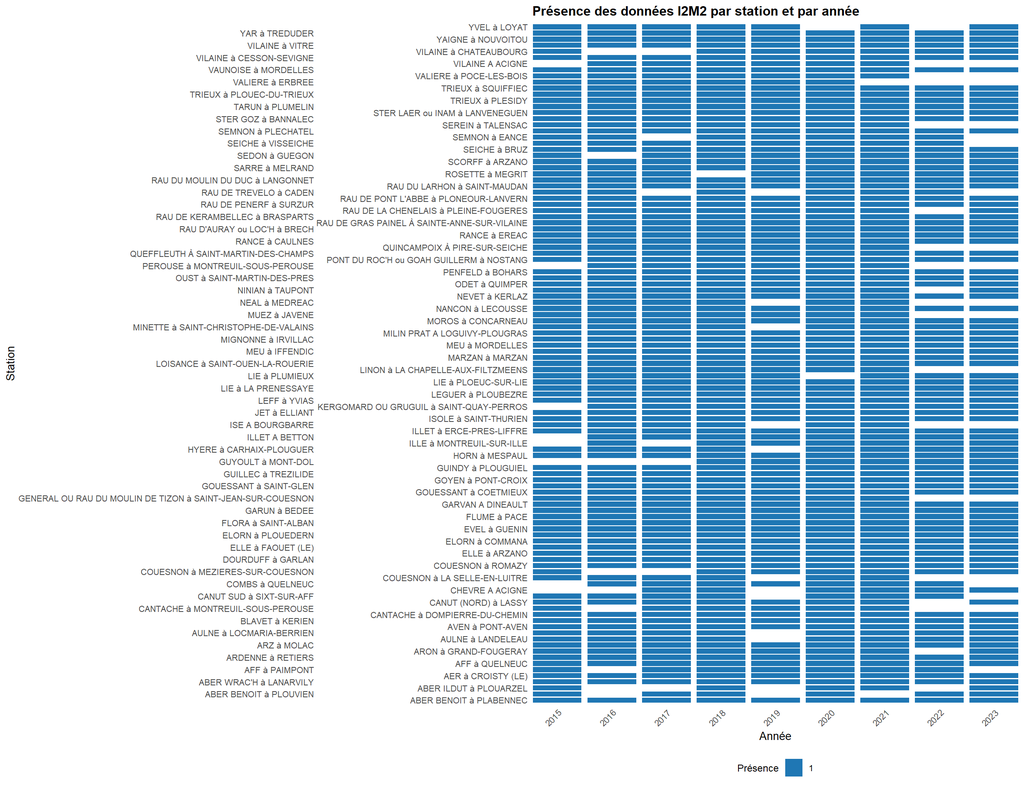

Fig.7 : Chroniques des données I2M2, autrice : Ilona Garcia

## Analyses

Les jeux de données sur lesquelles les analyses ont été réalisé sont les suivants :

- **clean_minv** : *code_station_hydrobio, libelle_station, code_indice, resultat_indice, date_prelevement, annee, longitude, lattitude, code_qualification.*
- **clean_ibd :** *code_station_hydrobio, libelle_station, code_indice, resultat_indice, date_prelevement, annee, longitude, lattitude, code_qualification.*
- **parametres_physico** : *code_station_hydrobio, libelle_station, code_parametres, resultat, date_prelevement, annee, code_qualification, code_fraction, code_support.*

### Analyses univariées

L’étude univariée des variables permet de décrire le jeu de données. Il est important de mesurer la répartition des valeurs que peut prendre une variable, notamment afin d’émettre des hypothèses pour la suite des analyses. Dans le but annoncé précédemment, l’étude des distributions des variables et les statistiques de tendance centrale et de dispersion sont réalisées au cours de cette analyse.

### Analyses spatiales des tendances temporelles des indices

La significativité de la tendance est obtenue grâce au test paramétrique de Mann-Kendall (Mann, 1945, Kendall, 1975), efficace pour traiter les tendances non linéaires, et robuste aux distributions non normales.

### Réalisation d’une “fenêtre glissante”

Les prélèvements physico-chimiques sont réalisés tout au long de l’année, parfois plusieurs fois par mois. La variabilité inter-annuelle étant négligé dans l’analyse, les résultats sont agrégés à l’issue de cette étape. En effet, cette méthode permet de choisir la période temporelle sur laquelle calculer une moyenne inter-annuelle pour chacun des paramètres. Les critères sur lesquels se base cette sélection sont :

- coefficient de corrélation
- durée de la période où la correlation est significative
- cohérence écologique

  Les étapes sont les suivantes :
- création d’un dataframe (df), avec toutes les combinaisons de mois-début et mois-fin pour chaque paramètre (soit 78 combinaisons possibles).
- réalisation d’un df avec les colonnes suivantes : *code_station_hydrobio, code_paramètre, annee, mois.*
- calcule des moyennes mensuelles intra paramètres physico-chimiques au niveau de chaque station.
- la fonction *calculer_indicateur* calcule la moyenne d’un paramètre sur une période donnée en regroupant les données par station et paramètre.
- les résultats sont obtenus pour chaque combinaison de mois à l’aide de *map2_df*, en appliquant la fonction *calculer_indicateur* sur les données.
- les moyennes des indices biologiques sont ensuite calculées par station et indice (supression du facteur temporel).
- les résultats des moyennes calculées sont fusionnés avec les données initiales pour permettre les comparaisons.
- les corrélations entre les paramètres physico-chimiques et les indices biologiques sont calculées à l’aide du test de Spearman.
- les résultats des corrélations sont visualisés avec un graphique utilisant *ggplot2*, en affichant les corrélations significatives avec un point gris.
- les noms des paramètres et des indices sont ajoutés pour une meilleure lisibilité, et les codes sont remplacés par des noms explicites.
- un graphique final est créé pour représenter les corrélations en fonction des mois de début et de fin, en utilisant des couleurs pour indiquer la force de la corrélation (on appelle ce genre de graphique fenêtre glissante).

Une fois les moyennes calculées sur la période retenue, le dataframe utilisé pour la suite des analyses est constitué de 232 lignes, où chaque *code_station_hydrobio* se voit attribuer une seule valeur pour chaque paramètre physico-chimique (14 colonnes correspondant aux 14 variables environnementales). Il s’agit du dataframe *resultat_physico_final*, qui a été transposé par la suite pour la réalisation des analyses suivantes.

### Analyses bivariées

Dans cette démarche exploratoire, on cherche à en savoir davantage sur les relations entre les différentes variables. Les analyses bivariées sont une aide à l’interpretation de l’ACP, qui guide la selection des variables explicatives afin d’éviter notamment la multicolinéarité lors de la modélisation.

Les analyses bivariées permettent d’évaluer le lien bivarié entre les indices et les métriques et par la suite les paramètres physico-chimiques deux à deux. Cela permet d’identifier les variables plus ou moins indépendantes.

Des matrices des corrélation sont réalisées, calculant les corrélations entre les indices et métriques puis entre paramètres physico-chimqiues, grâce au test de corrélation de Spearman. Ce test est robuse en cas de non normalité des distributions des variables et de relations non linéaires entre elles.

### Modèles linéaire généralisés

La modélisation par modèle linéaire généralisé permet d’analyser la relation entre une variable dépendante et un ensemble de variables explicatives, y compris lorsque la distribution de la variable s’écarte de la normalité . La fonction de modélisation prendra en variable dépendante les indices et métriques une à une, et en variables explicatives les paramètres physico-chimiques, selectionnés selon les analyses précédentes et des considérations écologiques théoriques. L’objectif du modèle est d’observer quelles sont les variables qui ont le plus d’influences sur les indices biologiques et les métriques et de connaitre leur poids.

Le modèle repose sur une loi normale (ou gaussienne), avec une fonction de lien “identité”. Ceci implique la validation de certaines hypothèses :

Le jeu de données utilisé regroupe les indices biologiques, les métriques et les paramètres physico-chimiques, consolidés à l’échelle des stations. Afin de supprimer la dimension temporelle, une moyenne a été calculée pour chaque variable. Ainsi, chaque station est représentée par une seule valeur moyenne par paramètre, indice ou métrique, permettant une analyse inter-stations. Le choix de la moyenne comme statistique est justifié par une volonté d’étudier des patterns généraux à l’échelle de chaque station.

L’expression utilisée est la suivante (en prenant l’exemple de l’I2M2 en tant que variable dépendante) :

*glm(I2M2 ~ O2dissous + NH4 + NO3 + Ptot, data = df_global_sans_stations, family = gaussian(link = “identity”))*

# Résultats

## 1. Analyses univariées

### a) Indices biologiques

L’étude étant exploratoire, il est crucial d’examiner le comportement global des variables. Les analyses sont réalisées sur les jeux de données *clean_minv*, *clean_ibd et parametres_physico*. Les distributions des variables seront décrites succinctement.

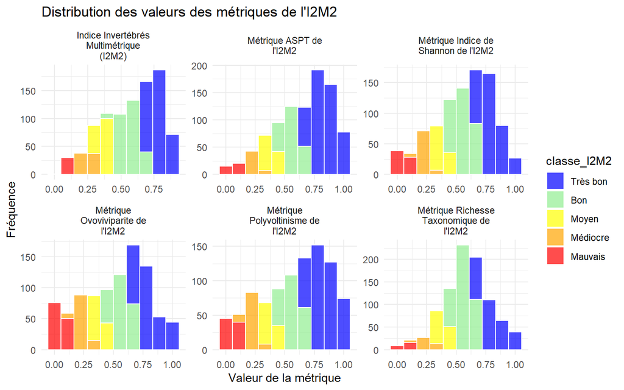

Fig.8 : Distribution de l’I2M2 et ses métriques, autrice : Ilona Garcia

Les couleurs associées aux classes d’états de l’I2M2 sont appliquées à chaque métrique pour faciliter la lecture.

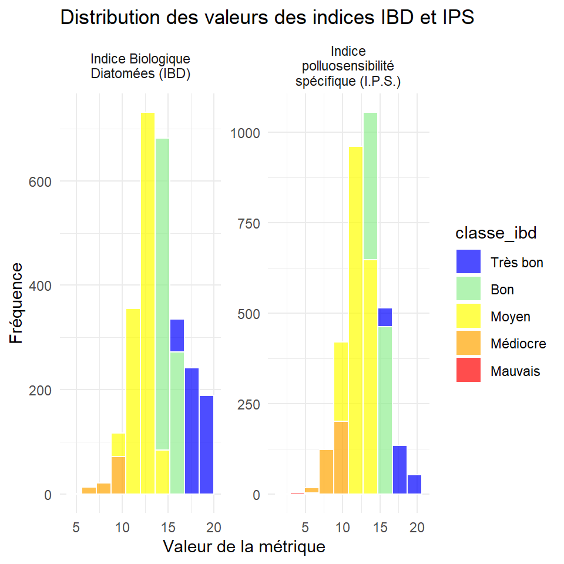

Fig.9 : Distribution de l’IBD et de l’IPS, autrice : Ilona Garcia

En revanche, les notes d’indices relatifs aux diatomées classés comme “Médiocre” et “Moyen” sont présentes en nombre largement supérieurs aux notes d’I2M2. Cela illustre les conditions trophiques des milieux, qui ne sont pas favorables au bon état écologique général.

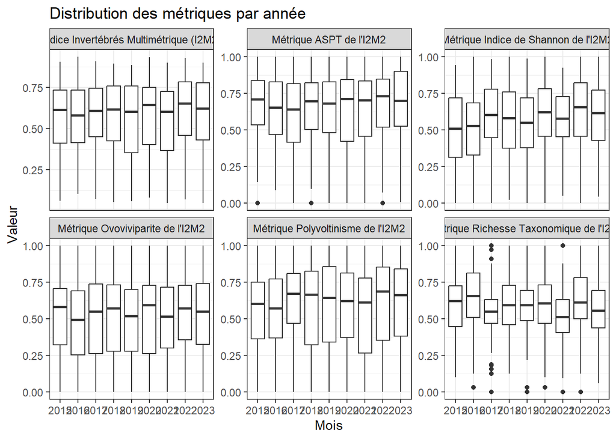

Fig.10 : Distribution inter-annuelle de l’indice I2M2 et ses métriques, autrice : Ilona Garcia

Comme on peut l’observer, les notes sont relativement stables au cours du temps, ce qui soutient l’hypothèse de faire une analyse inter-stations, en aggrégeant les valeurs. Le même comportement est observé pour les indices IBD et IPS.

### b) Paramètres physico-chimiques

L’effet saisonnier est intéressant à étudier, notamment dans l’objectif d’aggréger les valeurs en une statistique de tendance centrale telle qu’une moyenne pour réprésenter des phénomènes généraux à l’échelle des stations.

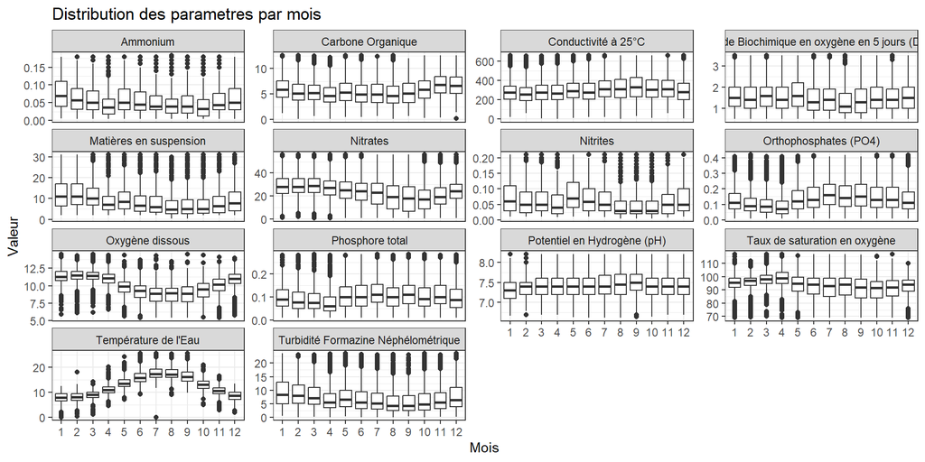

Fig.11 : Distribution des variables environnementales au cours de l’année, autrice : Ilona Garcia

## 2. Analyses spatiales des tendances temporelles

Afin de valider nos hypothèses sur l’inertie des indices biologiques en Bretagne, et donc faire une aggrégation de manière similaire aux paramètres physico-chimiques, les tendances à l’échelle de chaque station sont étudiées.

```
## list()
```

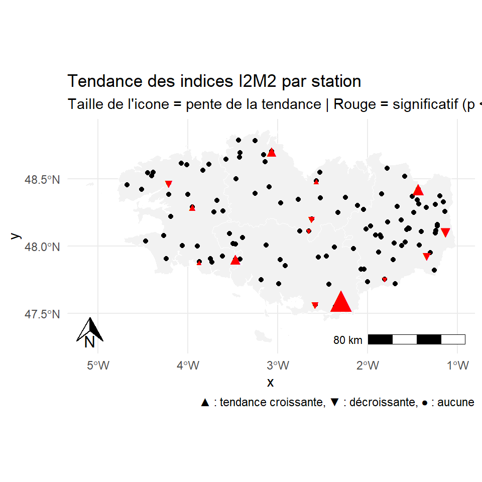

```
## list()
```

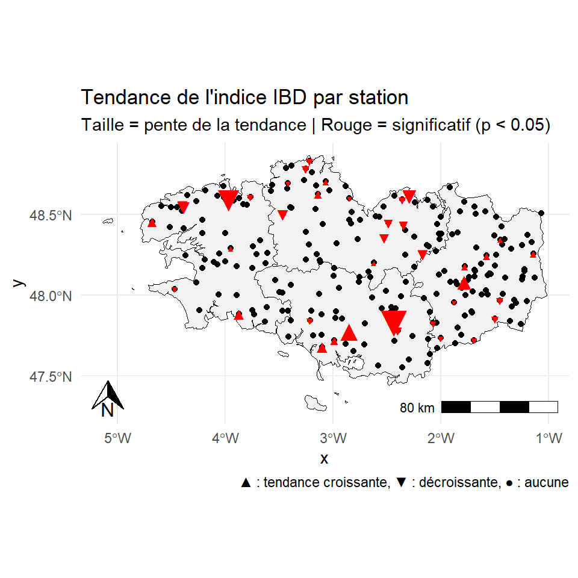

La variabilté temporelle sera donc négligée lors de l’étude, permettant d’aborder une analyse inter-stations.

## Choix de la période temporelle sur laquelle agréger

Une fois la méthode de la fenêtre glissante établie, la graphique suivant est obtenu :

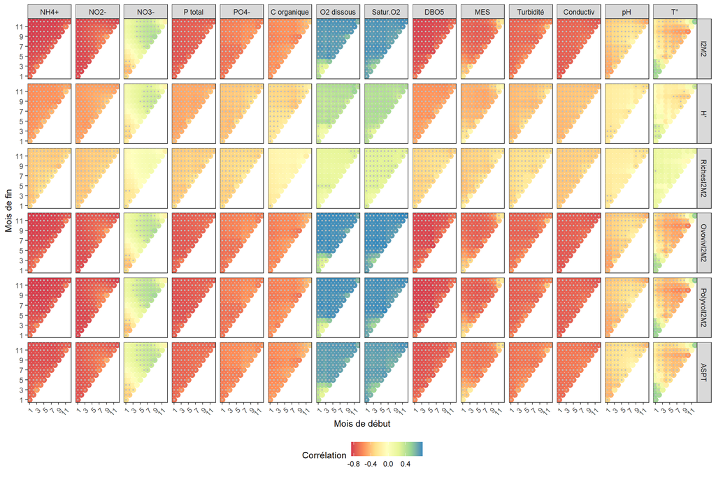

Fig.14 = Fenêtre glissante des corrélations entre les paramètres physico-chimiques et l’indice I2M2 et ses métriques, autrice : Ilona Garcia

D’après le graphique ci-dessous, trois periodes peuvent être distinguées :

- Nitrates : janvier à mars
- Oxygène dissous et taux de saturation en oxygène : mai à décembre
- Autres : annuelle

Les périodes présentant les corrélations significatives les plus fortes avec les indices biologiques ont été retenues pour l’analyse. La métrique de richesse taxonomique n’a pas été considéré dans ce choix. La période de janvier à mars a notamment été sélectionnée pour les nitrates, car elle correspond à la phase de lessivage des sols liée aux précipitations hivernales, entraînant un transfert important de nitrates issus des pratiques agricoles vers les cours d’eau. Les variables physico-chimiques ont ainsi été agrégées en calculant leur moyenne sur ces périodes spécifiques, afin de refléter au mieux les conditions environnementales et donc les pressions étudiées.

## Selection des variables pour la modélisation

D’après les résultats, l’I2M2 et l’IBD sont légèrement corrélés et donc ne sont pas entièrement indépendants. Cela peut indiquer des réponses biologiques à des pressions similaires.

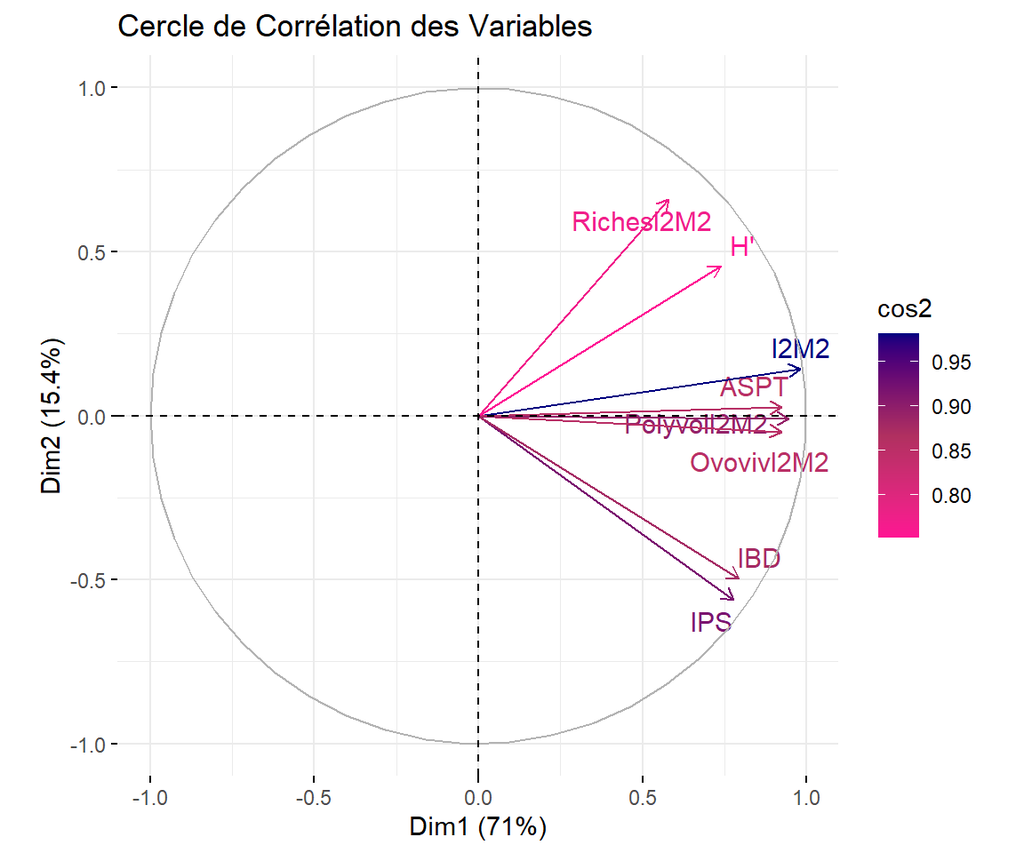

Fig.15 = Analyse des composantes principales des indices biologiques, autrice : Ilona Garcia

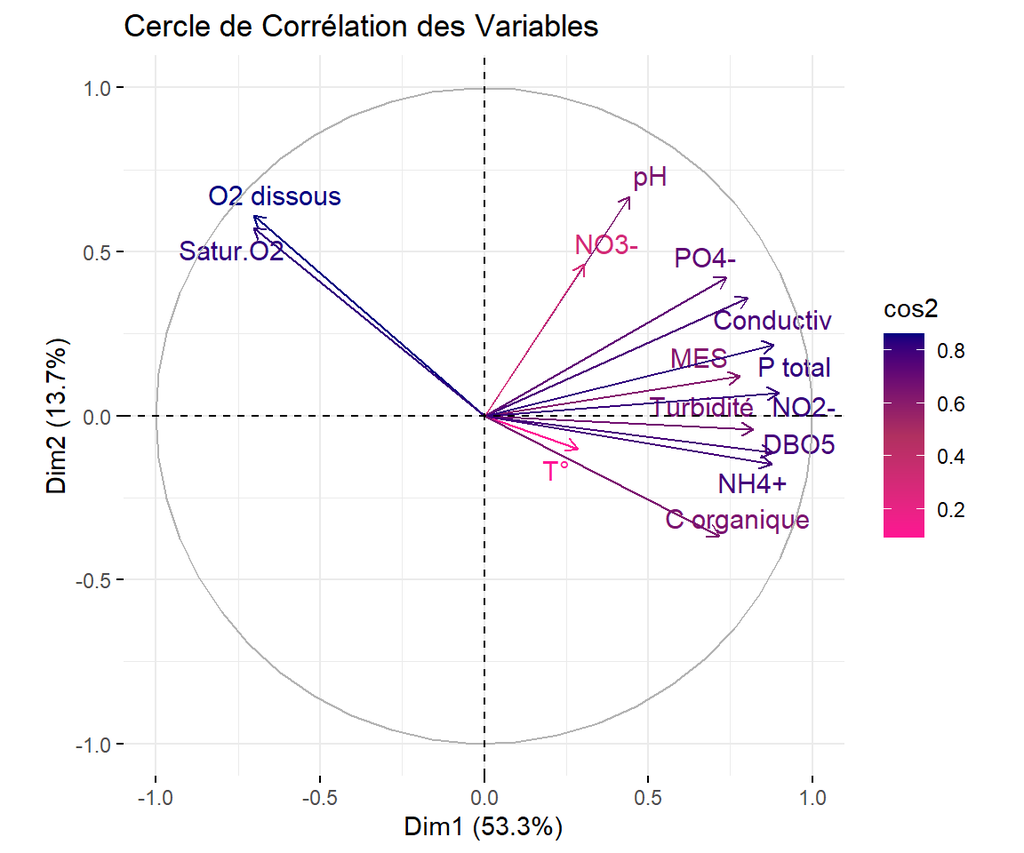

Fig.16 = Analyse des composantes principales des paramètres physico-chimiques, autrice : Ilona Garcia

Les variables explicatives retenues pour la modélisation ont été sélectionnées en fonction de leur contribution aux axes de l’ACP, de l’absence de colinéarité excessive, ainsi que de leur pertinence écologique. L’ammonium, forme azotée la plus toxique, a été conservé, tout comme les nitrates, fortement représentatifs des apports agricoles diffus caractéristiques du contexte breton. Le phosphore total a été retenu comme indicateur principal de la pression phosphorée, en raison de sa forte contribution au gradient de l’axe 1 de l’ACP. Enfin, l’oxygène dissous a été sélectionné en tant qu’indicateur de la qualité globale du milieu.

## L’influence des variables selectionnées sur les indices et métriques

La modélisation des réponses de chaque métriques était automatique grâce à la création d’une fonction de modélisation, où la variable dépendante change. La démarche sera détaillée pour l’indice I2M2 puis les résultats seront synthétisés en un tableau.

### Modélisation de la réponse de l’I2M2

Afin de valider l’hypothèse de non multicolinéarité, les coeffcients VIF sont calculés :

```
## Start:  AIC=-196.83
## I2M2 ~ O2dissous + NH4 + NO3 + Ptot
##
##             Df Deviance     AIC
## <none>           1.0162 -196.83
## - NO3        1   1.0396 -196.28
## - Ptot       1   1.0488 -195.29
## - O2dissous  1   1.1863 -181.49
## - NH4        1   1.2150 -178.81
```

```
## O2dissous       NH4       NO3      Ptot
##  2.030432  4.999526  1.133713  4.072420
```

Les résultats sont tous inférieurs à cinq, le critère de non multicolinéarité est respecté.

A la suite de cela, les test d’homoscédasticité et normalité des résidus sont réalisés, à l’aide des test associés.

```
##
##  studentized Breusch-Pagan test
##
## data:  model_simplifié
## BP = 3.3855, df = 2, p-value = 0.184
```

```
##
##  Shapiro-Wilk normality test
##
## data:  residuals(model_simplifié)
## W = 0.98926, p-value = 0.5227
```

La p-value étant supérieure à 0,05 dans les deux cas, les hypothèses d’homoscédasticité et normalité sont validées.

Par conséquent, on peut valider le modèle et tracer les graphiques associés.#

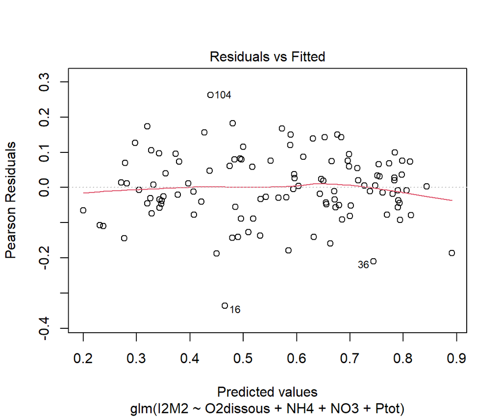

Fig.17 = Graphiques illustrants le modèle , autrice : Ilona Garcia

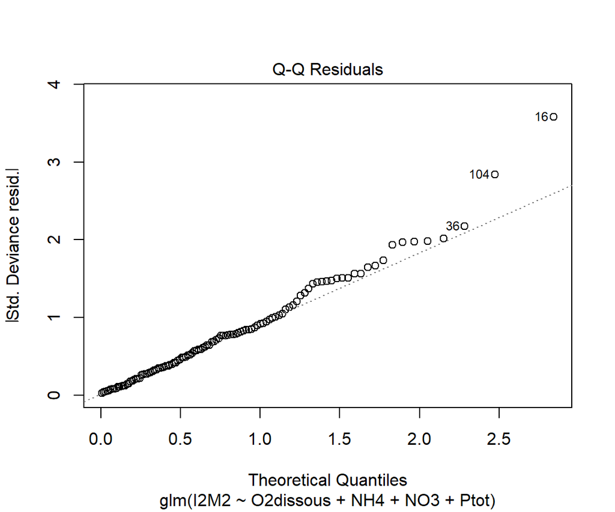

Fig.17 = Graphiques illustrants le modèle , autrice : Ilona Garcia

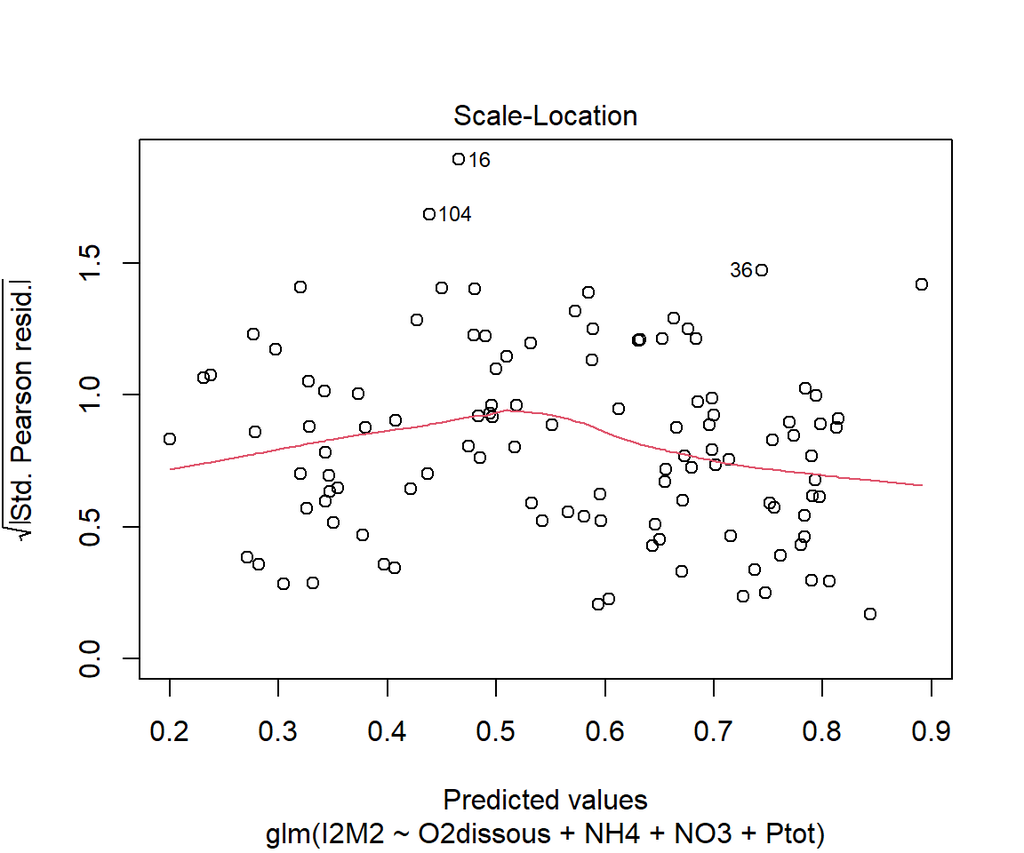

Fig.17 = Graphiques illustrants le modèle , autrice : Ilona Garcia

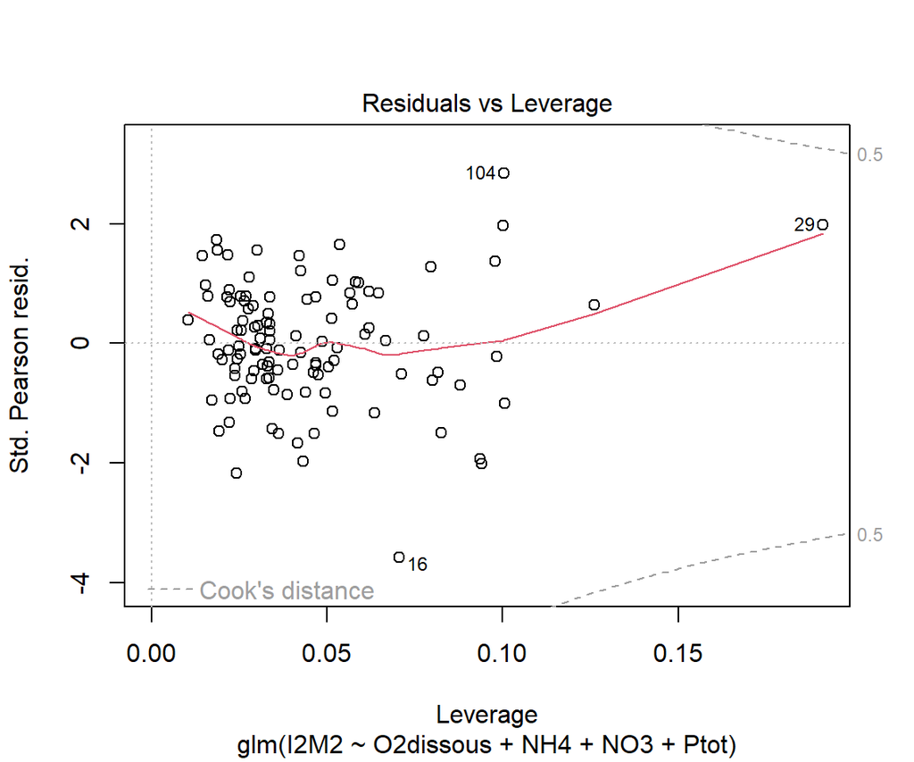

Fig.17 = Graphiques illustrants le modèle , autrice : Ilona Garcia

### Tableau récapitulatif

|  | metrique | (Intercept) | O2dissous | NH4 | NO3 | Ptot |
| --- | --- | --- | --- | --- | --- | --- |
| 1 | I2M2 | 0.29(.) | 0.06(***) | -3.25(***) |  | -0.74(.) |
| 2 | richesI2M2 | 0.71(***) |  |  |  | -1.31(***) |
| 3 | ovovivI2M2 |  | 0.11(***) | -3.48(***) | 0(*) | -0.9(.) |
| 4 | polyvolI2M2 |  | 0.1(***) | -3.3(***) |  | -1.52(**) |
| 5 | ASPT |  | 0.08(***) | -4.52(***) |  |  |
| 6 | ShannonI2M2 | 0.77(***) |  | -3.83(***) |  |  |
| 7 | IPS | 17.52(***) |  | -22.26(**) | -0.05(**) | -18.29(***) |
| 8 | IBD | 22.56(***) |  | -26.81(**) | -0.04(*) | -26.44(***) |

D’après les résultats, les indices et métriques liés à l’I2M2, à l’exception de la diversité de Shannon et la richesse taxonomique, sont sensibles à l’augmentation de la teneur en oxygène dissous dans l’eau, démontrant l’importance de cet élement pour maintenir un cours d’eau en bon état vis à vis des macro-invertébrés.